# Data Science II - Assignment

## 3. Model transport sales points

In this chapter, the available data will be used to indicate what factors explain the number of transport sale points in census sections as well as whether census sections have enough or too few transport sale points. As the steps for this analysis share a great overlap with the steps performed in the analysis of number of pharmacies, the more general explanations and reasoning behind certain steps will not be repeated, and the focus will be mainly on the interpretation of the results.

### Feature selection I

In this section feature selection based on the data frame without feature engineered variables is performed. The correlations of the selected variables with the dependent variable n_transport_salespoints are rather low. These low correlations forecasts a final regression model with low explanability.

```r
lasso <- train(
  n_transport_salespoints ~., data = df_2, method = "glmnet",
  trControl = trainControl("cv", number = 10),
  tuneGrid = expand.grid(alpha = 1, lambda = lambda)
)

#Retrieving coefficients
coef(lasso$finalModel, lasso$finalModel$lambdaOpt)
```

```
## 19 x 1 sparse Matrix of class "dgCMatrix"
##                                          s1
## (Intercept)                    1.227707e+00
## area                           4.464482e-03
## population                     8.580830e-05
## income_per_capita              4.836062e-06
## avg_age                        4.026359e-03
## spanish                       -1.311799e+00
## foreigners                     .
## europeans                      .
## non_european                  -2.591698e+00
## pcg_age_0_24                  -1.097419e+00
## pcg_expense_home               6.092304e-05
## ratio_expense_home            -5.899617e-04
## pcg_num_transaction_city      -1.686730e-03
## pcg_num_transaction_norm_city  1.864019e-03
## altitude                       1.217368e-04
## city_population               -7.743280e-09
## population_density            -8.992990e-07
## n_pharmacies                   1.120286e-01
## n_schools                      1.419398e-02
```

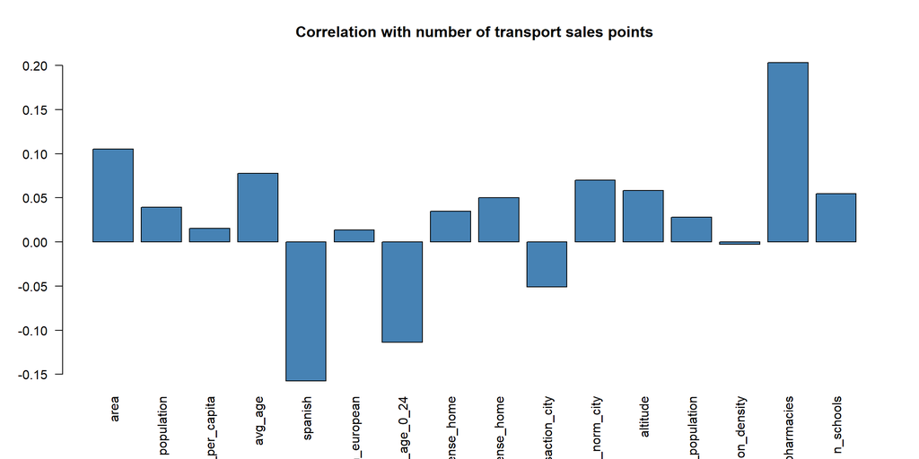

```r
# Extract coefficients for the optimal lambda
lasso_coef <- coef(lasso$finalModel, s = lasso$finalModel$lambdaOpt)

# Identify variables with non-zero coefficients and create list
non_zero_vars <- rownames(lasso_coef)[lasso_coef[, 1] != 0]
non_zero_vars <- non_zero_vars[-1]

#Keep only non zero coefficients
df_transport<- df_1 |>
  dplyr::select(all_of(non_zero_vars), n_transport_salespoints)

#Chekcing correlations -> low correlations
corr<- cor(df_transport$n_transport, df_transport[,-"n_transport_salespoints"])
corr<-round(corr,4)
barplot(corr, names.arg = names(df_transport[,-"n_transport_salespoints"]), col = "steelblue", las = 2 , main = "Correlation with number of transport sales points")
```

### Feature selection II

In this section feature selection based on the data frame with feature engineered variables is performed. The correlations of the selected variables with the dependent variable n_transport_sales_points are rather low. These low correlations forecasts again a final regression model with low explanability.

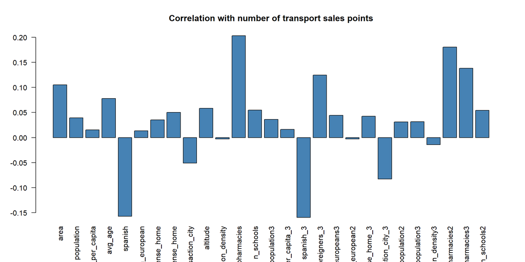

```r
df_transport_full_feature<- df_transport_full_feature |>
  drop_na()

lasso <- train(
  n_transport_salespoints ~., data = df_transport_full_feature, method = "glmnet",
  trControl = trainControl("cv", number = 10),
  tuneGrid = expand.grid(alpha = 1, lambda = lambda)
)

# Extract coefficients for the optimal lambda
lasso_coef <- coef(lasso$finalModel, s = lasso$finalModel$lambdaOpt)

# Identify variables with non-zero coefficients and create list
non_zero_vars <- rownames(lasso_coef)[lasso_coef[, 1] != 0]
non_zero_vars <- non_zero_vars[-1]

#Keep only non zero coefficients
df_transport_feature <- df_transport_full_feature |>
  dplyr::select(all_of(non_zero_vars), n_transport_salespoints)

#Chekcing correlations -> low correlations
corr<- cor(df_transport_feature$n_transport, df_transport_feature[,-"n_transport_salespoints"])
corr<-round(corr,4)
barplot(corr, names.arg = names(df_transport_feature[,-"n_transport_salespoints"]), col = "steelblue", las = 2 , main = "Correlation with number of transport sales points")
```

### Setting up test and training data

```r
set.seed(456)
training.samples <- df_transport_feature$n_transport_salespoints |>
  createDataPartition(p = 0.8, list = FALSE)
train.data  <- df_transport_feature[training.samples, ]
test.data <- df_transport_feature[-training.samples, ]

training.samples_sim <- df_transport$n_transport_salespoints |>
  createDataPartition(p = 0.8, list = FALSE)
train.data_sim  <- df_transport[training.samples_sim, ]
test.data_sim <- df_transport[-training.samples_sim, ]

train_control <- trainControl(method = "cv", number = 10)
```

### Regression models

#### Linear model

The linear model including the feature engineered variables shows a slightly higher $R^2$ and therefore the data frame including these feature engineered variables is selected to do the following regression analysis. However, one should note that the difference in $R^2$ is minimal and is most probably induced by the higher number of variables in the model including feature engineered variables.

```r
lm_model <- lm(n_transport_salespoints ~ ., data = train.data)

lm_fit <- train(n_transport_salespoints ~., data = train.data,
                method = "lm",
                trControl = train_control)


lm_fit_sim <- train(n_transport_salespoints ~., data = train.data_sim,
                method = "lm",
                trControl = train_control)


results <- resamples(list(linear = lm_fit, linear_sim = lm_fit_sim))
summary(results)
```

```
##
## Call:
## summary.resamples(object = results)
##
## Models: linear, linear_sim
## Number of resamples: 10
##
## MAE
##                 Min.   1st Qu.    Median      Mean   3rd Qu.      Max. NA's
## linear     0.3313441 0.3572557 0.3721428 0.3706737 0.3874125 0.4033292    0
## linear_sim 0.3581642 0.3651485 0.3745496 0.3748251 0.3812011 0.3995594    0
##
## RMSE
##                 Min.   1st Qu.    Median      Mean   3rd Qu.      Max. NA's
## linear     0.4243990 0.4593952 0.4838601 0.4891656 0.5175477 0.5525311    0
## linear_sim 0.4596292 0.4735904 0.4789684 0.4918629 0.5161304 0.5481288    0
##
## Rsquared
##                  Min.    1st Qu.     Median       Mean   3rd Qu.      Max. NA's
## linear     0.07151581 0.08209911 0.09816176 0.09912081 0.1142838 0.1283791    0
## linear_sim 0.06136384 0.07448550 0.08998474 0.09442179 0.1174361 0.1313450    0
```

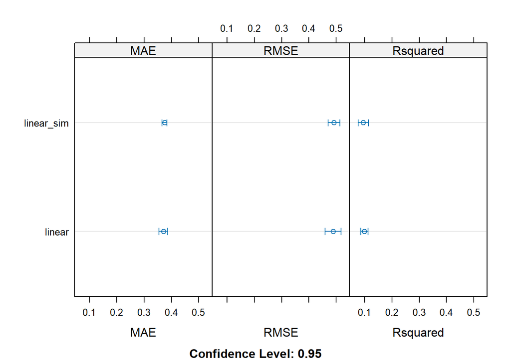

```r
dotplot(results)
```

#### Poisson

The poisson regression model is trained as this model is designed to estimate models with a non-negative discrete outcome variable [see Poisson chapter 1 for more information]. The poisson model does not improve the MAE, RMSE and $R^2$ considerably compared to the linear model.

```r
poisson_fit <- train(n_transport_salespoints ~ ., data = train.data,
                     method = "glm", family = poisson,
                     trControl = train_control)


results <- resamples(list(linear = lm_fit, poisson =poisson_fit))
summary(results)
```

```
##
## Call:
## summary.resamples(object = results)
##
## Models: linear, poisson
## Number of resamples: 10
##
## MAE
##              Min.   1st Qu.    Median      Mean   3rd Qu.      Max. NA's
## linear  0.3313441 0.3572557 0.3721428 0.3706737 0.3874125 0.4033292    0
## poisson 0.3434800 0.3516875 0.3646249 0.3648265 0.3698931 0.3926177    0
##
## RMSE
##              Min.   1st Qu.    Median      Mean   3rd Qu.      Max. NA's
## linear  0.4243990 0.4593952 0.4838601 0.4891656 0.5175477 0.5525311    0
## poisson 0.4447107 0.4545100 0.4907203 0.4891625 0.5147678 0.5406764    0
##
## Rsquared
##               Min.    1st Qu.     Median       Mean   3rd Qu.      Max. NA's
## linear  0.07151581 0.08209911 0.09816176 0.09912081 0.1142838 0.1283791    0
## poisson 0.04468185 0.08837290 0.10985700 0.10671288 0.1305685 0.1676712    0
```

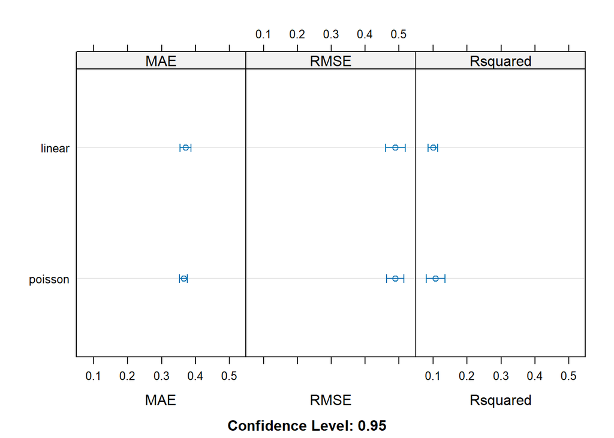

```r
dotplot(results)
```

#### Quasi-poisson regression

A possible issue for the poisson model is when the variance is significantly larger than the mean and overdispersion occurs. The quasi-poisson model is able to combat this as it assumes that variance can be modeled as a linear function of the mean and computes an overdispersion factor $\phi$ relating to the mean and variance: $Var(Y) = \phi * mean(Y)$ Hence, overdispersion is checked using the poisson model, however, no overdispersion was detected. Again the quasi- poisson model does not improve the MAE, RMSE and $R^2$ considerably compared to the former two models.

```r
#Checking overdispersion -> No overdispersion detected
poisson_model <- glm( n_transport_salespoints~ ., family = poisson, data = df_transport_feature)

check_overdispersion(poisson_model)
```

```
## # Overdispersion test
##
##        dispersion ratio =    0.890
##   Pearson's Chi-Squared = 3901.970
##                 p-value =        1
```

```
## No overdispersion detected.
```

```r
quasipoisson_model <- glm( n_transport_salespoints~ ., family = quasipoisson, data = train.data)

quasipoisson_fit <- train(n_transport_salespoints~., data = train.data,
                     method = "glm", family = "quasipoisson",
                     trControl = train_control)

results <- resamples(list(linear = lm_fit, poisson = poisson_fit, quasipoisson = quasipoisson_fit))
summary(results)
```

```
##
## Call:
## summary.resamples(object = results)
##
## Models: linear, poisson, quasipoisson
## Number of resamples: 10
##
## MAE
##                   Min.   1st Qu.    Median      Mean   3rd Qu.      Max. NA's
## linear       0.3313441 0.3572557 0.3721428 0.3706737 0.3874125 0.4033292    0
## poisson      0.3434800 0.3516875 0.3646249 0.3648265 0.3698931 0.3926177    0
## quasipoisson 0.3453279 0.3539154 0.3594664 0.3644301 0.3748972 0.3925600    0
##
## RMSE
##                   Min.   1st Qu.    Median      Mean   3rd Qu.      Max. NA's
## linear       0.4243990 0.4593952 0.4838601 0.4891656 0.5175477 0.5525311    0
## poisson      0.4447107 0.4545100 0.4907203 0.4891625 0.5147678 0.5406764    0
## quasipoisson 0.4565298 0.4727177 0.4825133 0.4885931 0.4988055 0.5372412    0
##
## Rsquared
##                    Min.    1st Qu.     Median       Mean   3rd Qu.      Max.
## linear       0.07151581 0.08209911 0.09816176 0.09912081 0.1142838 0.1283791
## poisson      0.04468185 0.08837290 0.10985700 0.10671288 0.1305685 0.1676712
## quasipoisson 0.05030623 0.08498449 0.09805374 0.10849971 0.1166863 0.1978344
##              NA's
## linear          0
## poisson         0
## quasipoisson    0
```

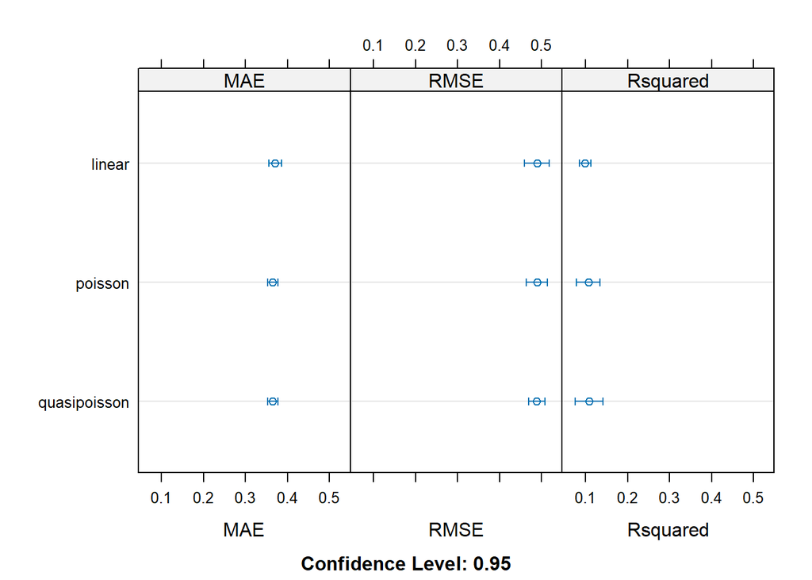

```r
dotplot(results)
```

#### Negative binomial regression analysis

The negative binomial model is again an algorithm that compensates for overdispersion by adding an overdispersion factor $\phi$ relating to the mean and variance: $Var(Y) = mean (Y) +\phi * mean(Y)^2$ . Again the negative model does not improve the MAE, RMSE and $R^2$ considerably compared to the former models. As the outcomes of these metrics were very similar for all of the models above, it is difficult to choose the best method based on these metrics. Therefore, the AIC’s from the models are compared to decide on the best method. The model with the lowest AIC is the negative binomial model. Hence, this model will be used to do the final predictions.

```r
negbin_model <- glm.nb(n_transport_salespoints ~ ., data = train.data)

neg_bin_fit <- train(n_transport_salespoints ~., data = train.data,
                     method = "glm.nb",
                     trControl = train_control)

results <- resamples(list(linear = lm_fit, poisson = poisson_fit, quasipoisson = quasipoisson_fit, negative_binomial = neg_bin_fit))
summary(results)
```

```
##
## Call:
## summary.resamples(object = results)
##
## Models: linear, poisson, quasipoisson, negative_binomial
## Number of resamples: 10
##
## MAE
##                        Min.   1st Qu.    Median      Mean   3rd Qu.      Max.
## linear            0.3313441 0.3572557 0.3721428 0.3706737 0.3874125 0.4033292
## poisson           0.3434800 0.3516875 0.3646249 0.3648265 0.3698931 0.3926177
## quasipoisson      0.3453279 0.3539154 0.3594664 0.3644301 0.3748972 0.3925600
## negative_binomial 0.3300602 0.3509958 0.3660665 0.3648155 0.3754932 0.4058073
##                   NA's
## linear               0
## poisson              0
## quasipoisson         0
## negative_binomial    0
##
## RMSE
##                        Min.   1st Qu.    Median      Mean   3rd Qu.      Max.
## linear            0.4243990 0.4593952 0.4838601 0.4891656 0.5175477 0.5525311
## poisson           0.4447107 0.4545100 0.4907203 0.4891625 0.5147678 0.5406764
## quasipoisson      0.4565298 0.4727177 0.4825133 0.4885931 0.4988055 0.5372412
## negative_binomial 0.4300543 0.4637030 0.4923968 0.4894527 0.5154505 0.5501157
##                   NA's
## linear               0
## poisson              0
## quasipoisson         0
## negative_binomial    0
##
## Rsquared
##                         Min.    1st Qu.     Median       Mean   3rd Qu.
## linear            0.07151581 0.08209911 0.09816176 0.09912081 0.1142838
## poisson           0.04468185 0.08837290 0.10985700 0.10671288 0.1305685
## quasipoisson      0.05030623 0.08498449 0.09805374 0.10849971 0.1166863
## negative_binomial 0.06275715 0.08560092 0.09489818 0.10384592 0.1120637
##                        Max. NA's
## linear            0.1283791    0
## poisson           0.1676712    0
## quasipoisson      0.1978344    0
## negative_binomial 0.1843295    0
```

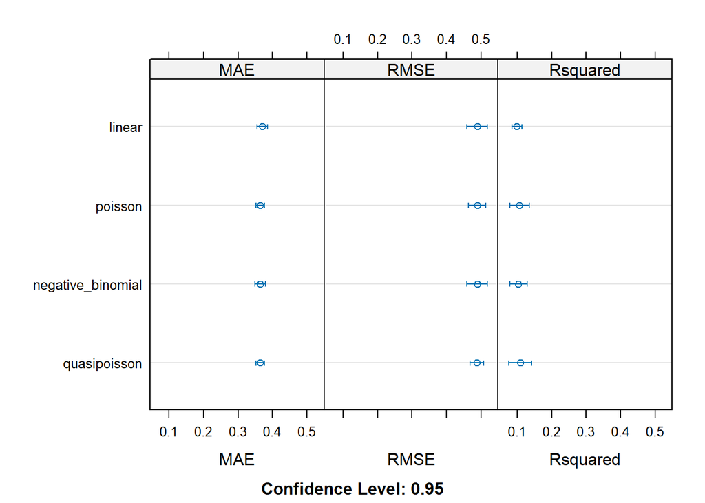

```r
dotplot(results)
```

```r
# Compare models using Achaiche information criteria (AIC)
aic_results <- AIC(lm_model, poisson_model, quasipoisson_model, negbin_model)

# Show results
list(AIC = aic_results)
```

```
## $AIC
##                    df      AIC
## lm_model           29 4993.279
## poisson_model      28 5299.937
## quasipoisson_model 29       NA
## negbin_model       29 4222.659
```

#### Validation of the best model: Negative binomial

The negative binomial model is validated by computing predictions based on the the test data. When plotting the predicted vs the actual values, the plot demonstrates that the model does not predict well the non zero values. Both the RMSE as well as the MSE are rather low values which indicate good model performance. As the MAE is 0.37, on average the model predictions are imprecise with 0.37 units. The RMSE value is somewhat larger as RMSE penalises large errors. The RMSE is 0.49, that is, on average the model predictions are imprecise with 0.49 units.

```r
predictions <- predict(neg_bin_fit, newdata = test.data)

summary(predictions)
```

```
##     Min.  1st Qu.   Median     Mean  3rd Qu.     Max.
## 0.008025 0.146118 0.225856 0.274486 0.342339 3.736778
```

```r
rounded_predictions <- round(predictions)

actual_values <- test.data$n_transport_salespoints

mae<- mean(abs(predictions - actual_values))
mae
```

```
## [1] 0.367866
```

```r
rmse <- sqrt(mean((predictions - actual_values)^2))
rmse
```

```
## [1] 0.4921594
```

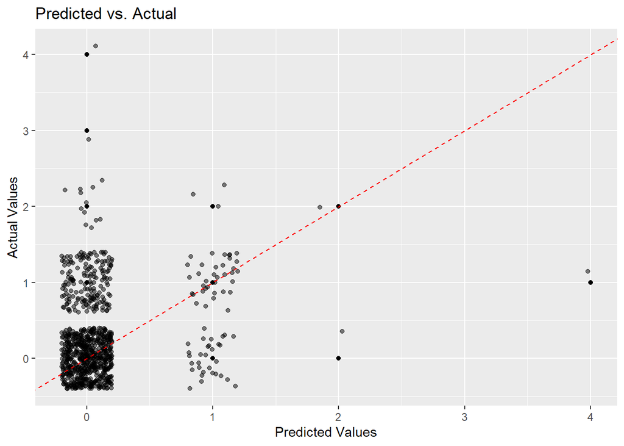

```r
ggplot(data = test.data, aes(x = rounded_predictions, y = n_transport_salespoints)) +
  geom_jitter(width = 0.2, alpha = 0.5)+
  geom_point() +
  geom_abline(intercept = 0, slope = 1, linetype = "dashed", color = "red") +
  labs(title = "Predicted vs. Actual",
       x = "Predicted Values",
       y = "Actual Values")
```

#### Model interpretation based on the best model: Negative binomial model

```r
neg_bin_fit_final <- train(n_transport_salespoints ~., data = df_transport_feature,
                     method = "glm.nb",
                     trControl = train_control)
summary(neg_bin_fit_final)
```

```
##
## Call:
## NULL
##
## Coefficients:
##                              Estimate Std. Error z value Pr(>|z|)
## (Intercept)                -1.345e+01  8.827e+00  -1.524 0.127509
## area                        8.827e-04  3.035e-03   0.291 0.771144
## population                  4.158e-04  1.457e-04   2.854 0.004316 **
## income_per_capita           1.399e-04  3.304e-05   4.235 2.28e-05 ***
## avg_age                     6.995e-02  9.569e-03   7.310 2.67e-13 ***
## spanish                     8.261e+00  1.462e+01   0.565 0.571989
## non_european               -2.565e+00  1.181e+01  -0.217 0.828109
## pcg_expense_home           -7.050e-03  3.283e-03  -2.148 0.031738 *
## ratio_expense_home          1.416e-02  1.090e-02   1.299 0.193885
## pcg_num_transaction_city    9.356e-02  2.774e-02   3.373 0.000744 ***
## altitude                    1.034e-04  3.790e-04   0.273 0.785100
## population_density          3.452e-06  3.860e-06   0.895 0.371039
## n_pharmacies                4.040e-01  1.552e-01   2.603 0.009229 **
## n_schools                   4.644e-02  4.435e-02   1.047 0.295029
## population3                -1.218e-11  1.176e-11  -1.035 0.300583
## income_per_capita_3        -8.161e-14  1.708e-14  -4.780 1.76e-06 ***
## spanish_3                  -6.241e+00  5.941e+00  -1.051 0.293417
## foreigners_3                1.600e+01  2.232e+01   0.717 0.473670
## europeans3                 -1.688e+01  1.361e+01  -1.240 0.215025
## non_european2              -1.860e+02  3.761e+02  -0.494 0.621048
## pcg_expense_home_3          5.201e-07  3.401e-07   1.529 0.126171
## pcg_num_transaction_city_3 -6.212e-06  1.430e-06  -4.343 1.41e-05 ***
## city_population2           -4.007e-12  4.637e-12  -0.864 0.387530
## city_population3            1.241e-18  1.436e-18   0.865 0.387230
## population_density3        -1.165e-15  6.657e-16  -1.749 0.080238 .
## n_pharmacies2              -4.789e-03  1.272e-01  -0.038 0.969975
## n_pharmacies3              -8.551e-03  2.577e-02  -0.332 0.739991
## n_schools2                 -1.223e-04  6.055e-03  -0.020 0.983885
## ---
## Signif. codes:  0 '***' 0.001 '**' 0.01 '*' 0.05 '.' 0.1 ' ' 1
##
## (Dispersion parameter for Negative Binomial(3711.698) family taken to be 1)
##
##     Null deviance: 3506.6  on 4413  degrees of freedom
## Residual deviance: 3040.6  on 4386  degrees of freedom
## AIC: 5302
##
## Number of Fisher Scoring iterations: 1
##
##
##               Theta:  3712
##           Std. Err.:  9676
## Warning while fitting theta: iteration limit reached
##
##  2 x log-likelihood:  -5243.981
```

```r
coef_summary <- coef(summary(neg_bin_fit_final))

options(scipen = 999)
exp_coefficients <- round(exp(coef_summary[, "Estimate"]),5)
exp_coefficients
```

```
##                (Intercept)                       area
##                    0.00000                    1.00088
##                 population          income_per_capita
##                    1.00042                    1.00014
##                    avg_age                    spanish
##                    1.07246                 3870.45234
##               non_european           pcg_expense_home
##                    0.07691                    0.99297
##         ratio_expense_home   pcg_num_transaction_city
##                    1.01426                    1.09808
##                   altitude         population_density
##                    1.00010                    1.00000
##               n_pharmacies                  n_schools
##                    1.49783                    1.04754
##                population3        income_per_capita_3
##                    1.00000                    1.00000
##                  spanish_3               foreigners_3
##                    0.00195              8845846.92751
##                 europeans3              non_european2
##                    0.00000                    0.00000
##         pcg_expense_home_3 pcg_num_transaction_city_3
##                    1.00000                    0.99999
##           city_population2           city_population3
##                    1.00000                    1.00000
##        population_density3              n_pharmacies2
##                    1.00000                    0.99522
##              n_pharmacies3                 n_schools2
##                    0.99149                    0.99988
```

```r
options(scipen = 0)

1-0.99481
```

```
## [1] 0.00519
```

### Score generation

The score to indicate whether a census section has sufficient or too few transport sales points is generated as follows. If the population is below 1000 one could argue that a transport sales point is not needed or infeasible. In this case, a score will be appointed of a value of 1 indicating there are enough transport sales points. In case of a population larger than 1000, if there is no sales point, it is appointed 0 indicating not enough and 1 sufficient if there is at least 1.

```r
df_transport_feature_log <-  df_transport_feature |>
  mutate(score_transport = if_else (population <1000, 1, if_else (n_transport_salespoints <1, 0,1))) |>
  dplyr::select(-n_transport_salespoints, -population)
```

### Training logistic regression

A logistic regression is trained to predict whether a census section has sufficient or too few transport sales points.

```r
set.seed(8910)
training.samples <- df_transport_feature_log$score_transport |>
  createDataPartition(p = 0.8, list = FALSE)
train.data  <- df_transport_feature_log[training.samples, ]
test.data <- df_transport_feature_log[-training.samples, ]

logistic_fit_train <- glm(score_transport ~., data =train.data , family = binomial)
```

#### Validating logistic regression

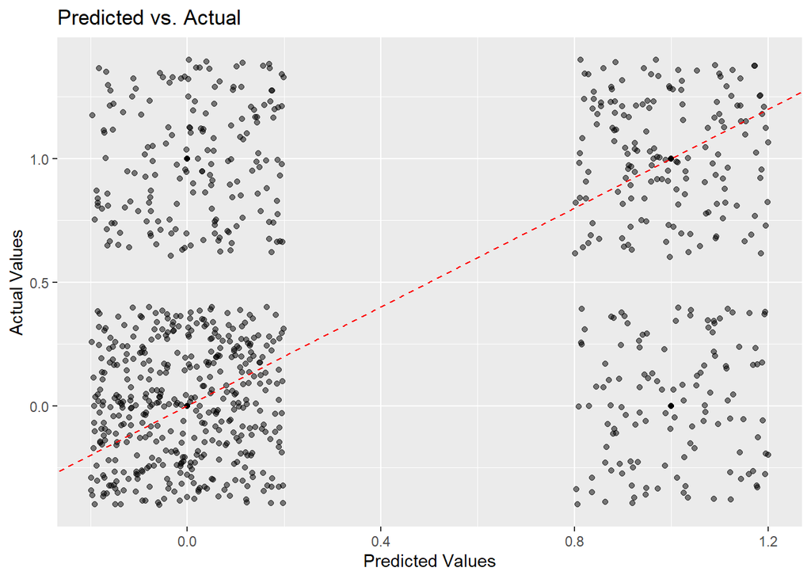

```r
# Make predictions
probabilities <- logistic_fit_train |>  predict(test.data, type = "response")
rounded_probabilities <- round(probabilities)
predicted.classes <- ifelse(probabilities > 0.5, 1, 0)

ggplot(data = test.data, aes(x = rounded_probabilities, y = score_transport)) +
  geom_jitter(width = 0.2, alpha = 0.5)+
  geom_point() +
  geom_abline(intercept = 0, slope = 1, linetype = "dashed", color = "red") +
  labs(title = "Predicted vs. Actual",
       x = "Predicted Values",
       y = "Actual Values")
```

```r
table(test.data$score_transport)
```

```
##
##   0   1
## 544 338
```

```r
confusionMatrix(as.factor(test.data$score_transport), as.factor(predicted.classes))
```

```
## Confusion Matrix and Statistics
##
##           Reference
## Prediction   0   1
##          0 421 123
##          1 178 160
##
##                Accuracy : 0.6587
##                  95% CI : (0.6264, 0.69)
##     No Information Rate : 0.6791
##     P-Value [Acc > NIR] : 0.908448
##
##                   Kappa : 0.2551
##
##  Mcnemar's Test P-Value : 0.001855
##
##             Sensitivity : 0.7028
##             Specificity : 0.5654
##          Pos Pred Value : 0.7739
##          Neg Pred Value : 0.4734
##              Prevalence : 0.6791
##          Detection Rate : 0.4773
##    Detection Prevalence : 0.6168
##       Balanced Accuracy : 0.6341
##
##        'Positive' Class : 0
##
```

```r
roc <- roc(as.factor(test.data$score_transport), probabilities)
```

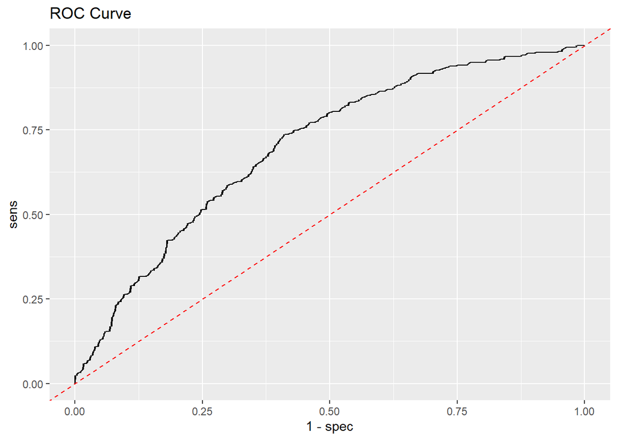

```r
sens <- roc$sensitivities
spec <- roc$specificities

ggplot(data.frame(sens,spec), aes(x=1-spec, y=sens)) + geom_line()+
  geom_abline(intercept = 0, slope = 1, linetype = "dashed", color = "red")+
  labs(title = "ROC Curve")
```

#### Model interpretation and visualisation

```r
logistic_fit <- glm(score_transport ~., data =df_transport_feature_log , family = binomial)
summary(logistic_fit)
```

```
##
## Call:
## glm(formula = score_transport ~ ., family = binomial, data = df_transport_feature_log)
##
## Coefficients:
##                              Estimate Std. Error z value Pr(>|z|)
## (Intercept)                 5.064e-01  1.372e+01   0.037 0.970563
## area                        1.285e-02  5.892e-03   2.181 0.029193 *
## income_per_capita           1.316e-04  4.011e-05   3.281 0.001033 **
## avg_age                     1.399e-01  1.111e-02  12.598  < 2e-16 ***
## spanish                     3.052e+00  1.844e+01   0.166 0.868529
## non_european               -1.278e+01  1.308e+01  -0.977 0.328326
## pcg_expense_home           -7.708e-03  3.868e-03  -1.993 0.046263 *
## ratio_expense_home          5.156e-02  1.325e-02   3.890 0.000100 ***
## pcg_num_transaction_city   -1.081e-01  1.401e-01  -0.772 0.440115
## altitude                    2.629e-04  5.777e-04   0.455 0.649013
## population_density         -1.172e-06  3.981e-06  -0.294 0.768480
## n_pharmacies                1.465e-01  1.813e-01   0.808 0.418845
## n_schools                  -2.817e-02  5.458e-02  -0.516 0.605830
## population3                -3.229e-11  9.060e-12  -3.564 0.000365 ***
## income_per_capita_3        -5.286e-14  2.016e-14  -2.622 0.008752 **
## spanish_3                  -3.072e+00  7.375e+00  -0.417 0.676960
## foreigners_3                2.568e+00  3.054e+01   0.084 0.932975
## europeans3                 -3.636e+00  1.699e+01  -0.214 0.830517
## non_european2               1.690e+02  3.995e+02   0.423 0.672300
## pcg_expense_home_3          6.378e-09  4.045e-07   0.016 0.987422
## pcg_num_transaction_city_3  3.753e-07  5.832e-06   0.064 0.948688
## city_population2           -7.913e-12  5.408e-12  -1.463 0.143382
## city_population3            2.458e-18  1.674e-18   1.469 0.141955
## population_density3        -4.107e-16  5.951e-16  -0.690 0.490050
## n_pharmacies2              -2.746e-02  1.642e-01  -0.167 0.867173
## n_pharmacies3               1.685e-02  3.474e-02   0.485 0.627633
## n_schools2                  4.537e-03  8.601e-03   0.528 0.597829
## ---
## Signif. codes:  0 '***' 0.001 '**' 0.01 '*' 0.05 '.' 0.1 ' ' 1
##
## (Dispersion parameter for binomial family taken to be 1)
##
##     Null deviance: 5913.0  on 4413  degrees of freedom
## Residual deviance: 5164.1  on 4387  degrees of freedom
## AIC: 5218.1
##
## Number of Fisher Scoring iterations: 8
```

```r
# Extracting coefficients using summary()
coef_summary <- coef(summary(logistic_fit))

options(scipen = 999)
# Exponentiating coefficients
exp_coefficients <- round(exp(coef_summary[, "Estimate"]), 5)
exp_coefficients
```

```
##                                                                      (Intercept)
##                                                                          1.65939
##                                                                             area
##                                                                          1.01293
##                                                                income_per_capita
##                                                                          1.00013
##                                                                          avg_age
##                                                                          1.15022
##                                                                          spanish
##                                                                         21.15193
##                                                                     non_european
##                                                                          0.00000
##                                                                 pcg_expense_home
##                                                                          0.99232
##                                                               ratio_expense_home
##                                                                          1.05291
##                                                         pcg_num_transaction_city
##                                                                          0.89751
##                                                                         altitude
##                                                                          1.00026
##                                                               population_density
##                                                                          1.00000
##                                                                     n_pharmacies
##                                                                          1.15782
##                                                                        n_schools
##                                                                          0.97223
##                                                                      population3
##                                                                          1.00000
##                                                              income_per_capita_3
##                                                                          1.00000
##                                                                        spanish_3
##                                                                          0.04631
##                                                                     foreigners_3
##                                                                         13.04306
##                                                                       europeans3
##                                                                          0.02636
##                                                                    non_european2
## 24998668360117004230428660064064444626242628840840666062800400424448260644.00000
##                                                               pcg_expense_home_3
##                                                                          1.00000
##                                                       pcg_num_transaction_city_3
##                                                                          1.00000
##                                                                 city_population2
##                                                                          1.00000
##                                                                 city_population3
##                                                                          1.00000
##                                                              population_density3
##                                                                          1.00000
##                                                                    n_pharmacies2
##                                                                          0.97291
##                                                                    n_pharmacies3
##                                                                          1.01699
##                                                                       n_schools2
##                                                                          1.00455
```

```r
options(scipen = 0)
```

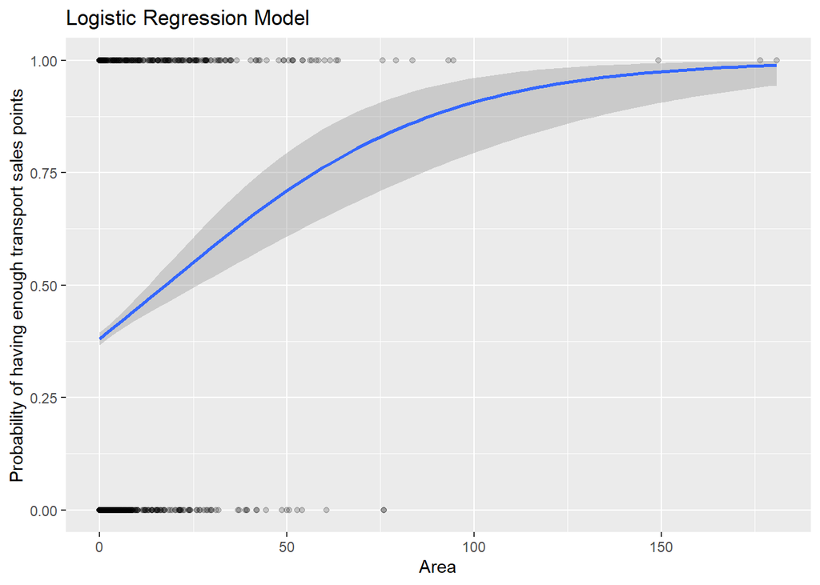

```r
df_transport_feature_log|>
  ggplot(aes(area, score_transport)) +
  geom_point(alpha = 0.2) +
  geom_smooth(method = "glm", method.args = list(family = "binomial")) +
  labs(
    title = "Logistic Regression Model",
    x = "Area",
    y = "Probability of having enough transport sales points"
    )
```

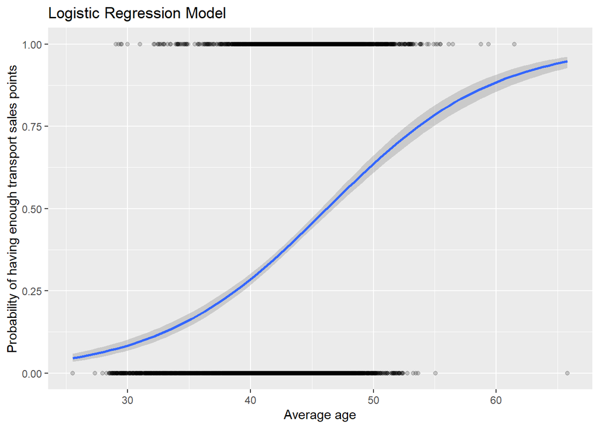

```r
df_transport_feature_log|>
  ggplot(aes(avg_age, score_transport)) +
  geom_point(alpha = 0.2) +
  geom_smooth(method = "glm", method.args = list(family = "binomial")) +
  labs(
    title = "Logistic Regression Model",
    x = "Average age",
    y = "Probability of having enough transport sales points"
    )
```

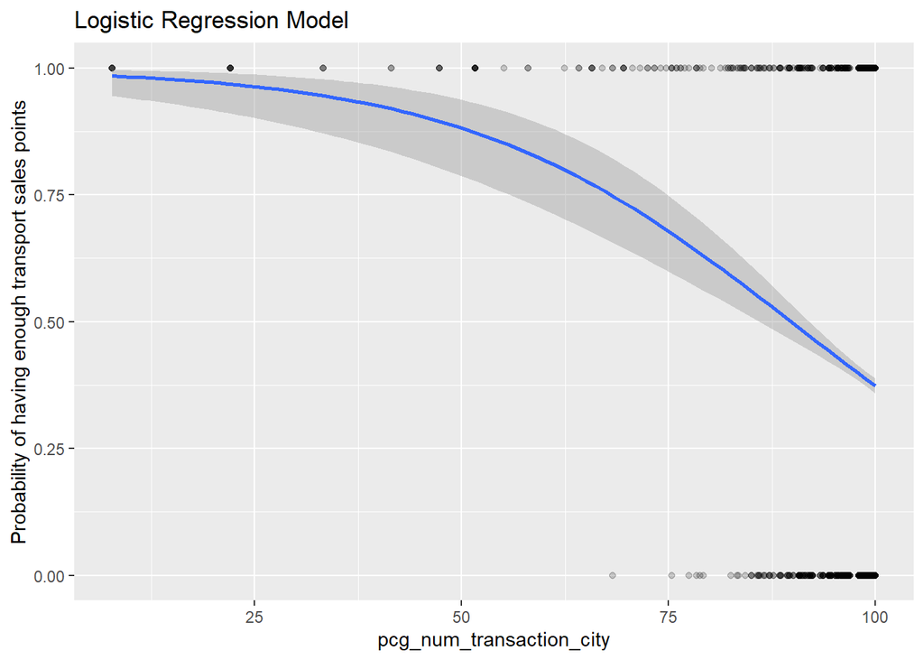

```r
df_transport_feature_log|>
  ggplot(aes(pcg_num_transaction_city, score_transport)) +
  geom_point(alpha = 0.2) +
  geom_smooth(method = "glm", method.args = list(family = "binomial")) +
  labs(
    title = "Logistic Regression Model",
    x = "pcg_num_transaction_city",
    y = "Probability of having enough transport sales points"
    )
```

## Discussion

For all three outcome variables: n_pharmacies, n_schools and n_transport_salepoints models were computed to indicate what factors are related to having sufficient or too few of these facilities. For all models, rather few and low impacting coefficients were found. Also, the coefficients were often difficult to interpret due to the highly differing scales of the independent and the dependent variables. It is recommended to do similar analysis with scaled data sets. Moreover, a larger data set with more diverging variables could enhance explainability of the models which are rather low in this report.